# Case Study Bellabeat

Mohammad Saeed Angiz

2026-08-25

```r
library(tidyverse)
library(readr)
library(ggplot2)
library(tibble)
library(lubridate)
library(janitor)
library(scales)
library(knitr)
library(dplyr)
Sys.setlocale("LC_TIME", "C")  # ensuring English weekday names regardless of system locale
```

```
## [1] "C"
```

# Executive Summary

Two months of Fitbit tracker data from 35 users shows the wellness market has been selling the wrong habit. The strongest relationship in the data is not between steps and health it is between **Sitting still and sleeping badly**.

```r
tibble(
  Metric = c("Users Analysed", "Days of tracked activity", "Nights of sleep",
             "Median device wear rate", "Average sedentary time per day",
             "Nights under 7 hours of sleep", "Days reaching 10,000 steps",
             "Correlation: sedentary time vs sleep"),
  Value = c(
    as.character(n_users),
    comma(nrow(worn)),
    comma(nrow(sleep)),
    percent(median((worn |>  count(id, name = "d") |>
      left_join(daily |>  distinct(id, period) |>
        left_join(daily |>  group_by(period) |>
          summarise(w = as.numeric(max(date) - min(date)) + 1, .groups = "drop"),
          by = "period") |>  group_by(id) |>
        summarise(w = sum(w), .groups = "drop"), by = "id") |>
      mutate(r = d / w))$r), 1),
    paste0(round(mean(worn$sedentary_minutes) / 60, 1), " hours"),
    percent(mean(sleep$hours_asleep < 7), 0.1),
    percent(mean(worn$total_steps >= 10000), 0.1),
    round(cor((worn |>  inner_join(sleep, by = c("id", "date")))$sedentary_minutes,
              (worn |>  inner_join(sleep, by = c("id", "date")))$hours_asleep), 2)
  )
) |>  kable(caption = "Headline figures")
```

Headline figures

| Metric | Value |
| --- | --- |
| Users Analysed | 35 |
| Days of tracked activity | 1,235 |
| Nights of sleep | 882 |
| Median device wear rate | 63% |
| Average sedentary time per day | 15.9 hours |
| Nights under 7 hours of sleep | 49.1% |
| Days reaching 10,000 steps | 34.0% |
| Correlation: sedentary time vs sleep | -0.48 |

**Top three recommendations:** replacing the fixed 10,000-step goal with an adaptive one; Market the Bellabeat app on the sit less sleep better link; And time notifications to the two hours when users are already moving.

# 1. Ask : Summary of the business task

> **Deliverable 1: A clear Summary of the business task**

Bellabeat is a high tech manufacturer of health focused products for women, founded in 2013 by Urška Sršen and Sando Mur. The product line comprises the Bellabeat app, the Leaf tracker, the Time watch, the Spring water bottle and a subscription membership.

Urška Sršen believes analysing smart device fitness data could unlock new growth. She has asked the marketing analytics team to analyse usage data from **non Bellabeat smart devices**, select **one Bellabeat product**, and produce high level recommendations for marketing strategy.

### The business task

> Identify how consumers actually use non-Bellabeat smart devices, and determine which of the resulting behavioural gaps Bellabeat is positioned to close through its marketing of the Bellabeat app.

### Guiding questions this report answers

1. What are some trends in smart device usage?
2. How could these trends apply to Bellabeat customers?
3. How could these trends help influence Bellabeat marketing strategy?

### Key stakeholders

| Stakeholder | Role | What they need from this |
| --- | --- | --- |
| Urška Sršen | Cofounder, Chief Creative Officer | Growth opportunities grounded in evidence |
| Sando Mur | Cofounder, executive team | Analytically sound conclusions |
| Marketing analytics team | Colleagues | A reproducible basis for campaign decisions |

### Product selected

The **Bellabeat App**. It connects every device in the range, is the surface where behavioural nudges are delivered, and drives the membership subscription so insights about behaviour can be acted on there fastest and most cheaply.

# 2. Prepare : Description of data sourceses

> **Deliverable 2: A Description of all Data sources used**

## Source and licensing

[Download the dataset on Kaggle ↗](https://www.kaggle.com/datasets/arashnic/fitbit)

| Item | Detail |
| --- | --- |
| Dataset | FitBit Fitness Tracker Data |
| Made available by | Mobius, via [Kaggle](https://www.kaggle.com/datasets/arashnic/fitbit) |
| Licence | CC0 public domain, no restriction on use |
| Collection | Amazon Mechanical Turk survey, 12 March to 12 May 2016 |
| Consent | Participants explicitly consented to submit personal tracker data |
| Privacy | No names, addresses or demographics; users identified by numeric ID only |
| Storage | Downloaded and stored locally in dated subfolders; originals unmodified |

Because the data is CC0 and carries no personal identifiers, there are no licensing, Privacy or security barriers to this analysis. All cleaning was done on copies; the source `.csv` files were never overwritten.

## How the data is organised

The dataset ships as **two Export folders covering consecutive months**:

- `mturkfitbit_export_3.12.16-4.11.16` - 12 Mar to 11 Apr 2016
- `mturkfitbit_export_4.12.16-5.12.16` - 12 Apr to 12 May 2016

Both contain the same Measurements at four Level of details : daily, hourly, minute and second in long (`Narrow`) and wide formats.

**Most published Analyses of this Dataset use only the second folder.** Both folders share an identical `dailyActivity_merged.csv` schema, so this analysis combines them:

```r
tibble(
  Scope = c("Typical single folder analysis", "This analysis (both folders)"),
  Users = c(33, n_users),
  `Days covered` = c(31, as.numeric(max(daily$date) - min(daily$date)) + 1),
  `Sleep nights` = c(410, nrow(sleep))
) |>  kable(caption = "Combining both export folders roughly doubles the evidence base")
```

Combining both export folders roughly doubles the evidence base

| Scope | Users | Days covered | Sleep nights |
| --- | --- | --- | --- |
| Typical single folder analysis | 33 | 31 | 410 |
| This analysis (both folders) | 35 | 62 | 882 |

## Files selected, and why

```r
steps_only <- read_csv(file.path(P2, "dailySteps_merged.csv"), show_col_types = FALSE)
activity   <- read_csv(file.path(P2, "dailyActivity_merged.csv"), show_col_types = FALSE)

check <- steps_only |>  rename(day = ActivityDay) |>
  inner_join(activity |>  rename(day = ActivityDate), by = c("Id", "day"))

cat("User days compared:", nrow(check), "\n")
```

```
## User days compared: 578
```

```r
cat("Step counts identical in every row:", all(check$StepTotal == check$TotalSteps), "\n")
```

```
## Step counts identical in every row: TRUE
```

| File used | Purpose |
| --- | --- |
| `dailyActivity_merged` | Steps, distance, intensity minutes and calories per day |
| `hourlySteps_merged` | Time of day activity patterns |
| `sleepDay_merged` | Nightly sleep totals April period |
| `minuteSleep_merged` | Aggregated to nights to extend sleep coverage into March |
| `weightLogInfo_merged` | Feature adoption and manual entry Behaviour |

`heartrate_seconds_merged.csv` was Excluded: 86 MB covering only 14 of 35 users, too small a subsample to support a finding. Minute level activity files were excluded as redundant to the hourly and daily aggregates.

## Data integrity and credibility does it ROCCC?

```r
tibble(
  Criterion = c("Reliable", "Original", "Comprehensive", "Current", "Cited"),
  Assessment = c("Weak", "Weak", "Weak", "Poor", "Good"),
  Detail = c(
    paste0(n_users, " self selected participants; no independent verification"),
    "Third party redistribution, not collected by Fitbit or Bellabeat",
    "No age, gender, height, location or health baseline recorded",
    "Collected in 2016; wearable hardware and user expectations have since changed",
    "Clearly sourced and openly licensed under CC0"
  )
) |>  kable(caption = "ROCCC assessment of the FitBit Fitness Tracker Data")
```

ROCCC assessment of the FitBit Fitness Tracker Data

| Criterion | Assessment | Detail |
| --- | --- | --- |
| Reliable | Weak | 35 self selected participants; no independent verification |
| Original | Weak | Third party redistribution, not collected by Fitbit or Bellabeat |
| Comprehensive | Weak | No age, gender, height, location or health baseline recorded |
| Current | Poor | Collected in 2016; wearable hardware and user expectations have since changed |
| Cited | Good | Clearly sourced and openly licensed under CC0 |

**This data does not ROCCC well, and that is stated before the findings rather than after.** The sample is small and self-selected, and it contains **no gender field** a material limitation when Analysing on behalf of a company selling exclusively to women. Every finding below is a directional signal to be validated against Bellabeat’s own data, not a conclusion to commit budget to.

Sršen suggested considering an additional dataset to address these limits. The most valuable addition would be Bellabeat’s own app telemetry, where gender, age and product line are known.

# 3. Process : Documentation of data cleaning

> **Deliverable 3: Documentation of any cleaning or manipulation of data**

## Tools chosen

**R with the tidyverse**, for three reasons: the dataset exceeds Excel’s comfortable working range at minute level `over 1.3 million rows`; every cleaning step is recorded as code and is therefore reproducible and auditable; and the same environment handles cleaning, statistics and visualisation without exporting between tools. This document is written in R Markdown, so every figure quoted is generated at knit time rather than typed in by hand.

## Checking for errors

```r
tibble(
  Check = c("Duplicate rows in daily activity",
            "Duplicate rows in sleep (April roll up)",
            "Missing values in daily activity",
            "Days recording zero steps",
            "Weight entries with missing body fat value"),
  Result = c(
    sum(duplicated(daily_raw)),
    sum(duplicated(sleep_apr_raw)),
    sum(is.na(daily_raw)),
    sum(!daily$is_wear_day),
    sum(is.na(weight$fat))
  )
) |>  kable(caption = "Integrity checks Run before any analysis")
```

Integrity checks Run before any analysis

[output not shown]

## Cleaning steps used

1. **Combined both export folders** for daily activity, hourly steps and weight, after confirming identical Schemas. A `period` column preserves the source window for each row.
2. **Standardised column names** to `snake_case` using `janitor::clean_names()`.
3. **Parsed dates from text.** `read_csv()` imports `"4/12/2016"` as a character string; `lubridate::mdy()` and `mdy_hms()` convert these to date objects so they can be sorted, filtered and grouped by weekday.
4. **Removed duplicate records.** `sleepDay_merged.csv` contains three exact duplicate rows, a documented flaw in this dataset. removing duplication on `id` Plus `date` was applied to every table as a safeguard at the folder boundary.
5. **Separated non-wear days**.
6. **Aggregated March minute-level sleep to nightly totals**.
7. **Derived fields:** weekday, total active minutes, hours asleep, minutes awake in bed, sleep efficiency, and per user device wear rate.

## Handling non wear days

138 rows record zero steps alongside close to a full day of sedentary minutes. These represent a device left on a charger, not a participant who remained motionless for 24 hours:

```r
daily |>
  group_by(`Day type` = ifelse(is_wear_day, "Device worn", "Zero steps recorded")) |>
  summarise(Days = n(),
            `Mean sedentary minutes` = round(mean(sedentary_minutes)),
            `Mean calories` = round(mean(calories)), .groups = "drop") |>
  kable(caption = "Zero step days average close to 1,440 sedentary minutes, confirming non wear")
```

Zero step days average close to 1,440 sedentary minutes, confirming non wear

| Day type | Days | Mean sedentary minutes | Mean calories |
| --- | --- | --- | --- |
| Device worn | 1235 | 952 | 2336 |
| Zero steps recorded | 138 | 1367 | 1621 |

These rows were **excluded from all activity averages** but **kept for the device engagement analysis**, where they are the direct evidence of how often the tracker is worn. Including them in averages would understate activity by approximately 10%.

## Extending sleep coverage into March

`sleepDay_merged.csv` exists only in the April folder. Using it alone would draw activity from both months but sleep from one. `minuteSleep_merged.csv` covers March at minute level, where `value` is coded 1 = asleep, 2 = restless, 3 = awake, and every row represents one minute in bed. Counting rows per night yields time in bed; counting `value == 1` yields minutes asleep the same two measures the April file reports.

**Assumption declared:** sleep crosses midnight, so grouping by calendar date would split a single night into two records. Subtracting six hours before taking the date assigns before dawn minutes to the previous night. Records under 60 Minutes were dropped as fragments rather than nights. This 6 a.m cutoff is a Judgement call; excluding March entirely reduces the evidence base from 882 to 410 nights without changing the direction or meaning of any finding.

## Verifying the cleaned Data

```r
tibble(
  Table = c("Daily activity (worn days)", "Sleep", "Hourly steps", "Weight logs"),
  Rows = c(nrow(worn), nrow(sleep), nrow(hourly), nrow(weight)),
  Users = c(n_distinct(worn$id), n_distinct(sleep$id),
            n_distinct(hourly$id), n_distinct(weight$id)),
  `Date range` = c(
    paste(format(min(worn$date), "%d %b"), "-", format(max(worn$date), "%d %b %Y")),
    paste(format(min(sleep$date), "%d %b"), "-", format(max(sleep$date), "%d %b %Y")),
    paste(format(min(as_date(hourly$ts)), "%d %b"), "-", format(max(as_date(hourly$ts)), "%d %b %Y")),
    paste(format(min(weight$date), "%d %b"), "-", format(max(weight$date), "%d %b %Y"))
  )
) |>  kable(caption = "Cleaned tables ready for Analysis")
```

Cleaned tables ready for Analysis

| Table | Rows | Users | Date range |
| --- | --- | --- | --- |
| Daily activity (worn days) | 1235 | 35 | 12 Mar - 12 May 2016 |
| Sleep | 882 | 25 | 11 Mar - 12 May 2016 |
| Hourly steps | 46008 | 35 | 12 Mar - 12 May 2016 |
| Weight logs | 98 | 13 | 30 Mar - 12 May 2016 |

# 4. Analyze : Summary of the Analysis

> **Deliverable 4: An Analysis Summary**

The Analysis Proceeded in four passes. **Descriptive statistics** established baseline activity, sleep and calorie levels against published health benchmarks. **User level segmentation** grouped participants by average daily steps and by device wear rate always aggregating per user before comparing users, so that participants with more logged days do not dominate the averages. **Temporal aggregation** examined activity by hour of day and day of week. **Correlation and regression** tested the relationships between steps, calories, sedentary time and sleep duration.

`The central surprise:` the variable most strongly associated with sleep is not step count but **sedentary time**, and the relationship is roughly three times stronger. This Reframes the marketing proposition from motivating exercise to reducing sitting a substantially lower bar for the user and a claim no major competitor is currently making.

```r
sa <- worn |> inner_join(sleep, by = c("id", "date"))

tibble(
  Relationship = c("Daily steps vs calories burned",
                   "Sedentary minutes vs calories burned",
                   "Daily steps vs hours asleep",
                   "Sedentary minutes vs hours asleep"),
  `Pearson r` = c(
    round(cor(worn$total_steps, worn$calories), 3),
    round(cor(worn$sedentary_minutes, worn$calories), 3),
    round(cor(sa$total_steps, sa$hours_asleep), 3),
    round(cor(sa$sedentary_minutes, sa$hours_asleep), 3)
  ),
  n = c(nrow(worn), nrow(worn), nrow(sa), nrow(sa))
) |>  kable(caption = "Correlations tested. Association only causal direction is untested.")
```

Correlations tested. Association only causal direction is untested.

| Relationship | Pearson r | n |
| --- | --- | --- |
| Daily steps vs calories burned | 0.563 | 1235 |
| Sedentary minutes vs calories burned | 0.033 | 1235 |
| Daily steps vs hours asleep | -0.150 | 603 |
| Sedentary minutes vs hours asleep | -0.483 | 603 |

# 5. Share : Visualisations and key Findings

> **Deliverable 5: Supporting Visualisations and key Findings**

## Finding 1 : The device comes off, and it happens often

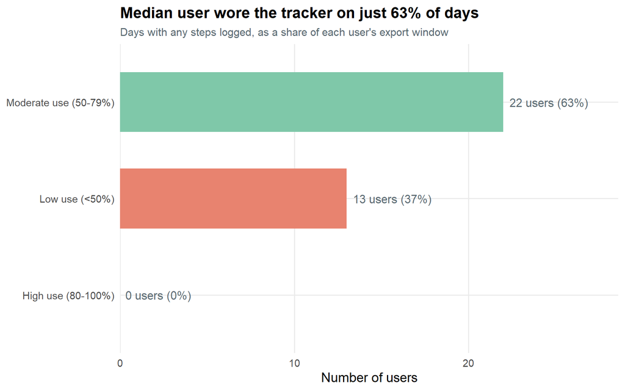

```r
period_len <- daily |>  group_by(period) |>
  summarise(days = as.numeric(max(date) - min(date)) + 1, .groups = "drop")

user_window <- daily |>  distinct(id, period) |>
  left_join(period_len, by = "period") |>
  group_by(id) |>  summarise(window_days = sum(days), .groups = "drop")

usage <- worn |>  count(id, name = "wear_days") |>
  left_join(user_window, by = "id") |>
  mutate(wear_rate = wear_days / window_days,
         segment = case_when(wear_rate >= 0.80 ~ "High use (80-100%)",
                             wear_rate >= 0.50 ~ "Moderate use (50-79%)",
                             TRUE              ~ "Low use (<50%)") |>
           factor(levels = c("High use (80-100%)", "Moderate use (50-79%)", "Low use (<50%)")))

usage_sum <- usage |>  count(segment, .drop = FALSE) |>  mutate(pct = n / sum(n))

ggplot(usage_sum, aes(reorder(segment, n), n, fill = segment)) +
  geom_col(width = .62) +
  geom_text(aes(label = paste0(n, " users (", percent(pct, 1), ")")),
            hjust = -0.08, size = 3.8, colour = SLATE) +
  coord_flip() + scale_y_continuous(expand = expansion(c(0, .3))) +
  scale_fill_manual(values = c(TEAL, MINT, CORAL), guide = "none") +
  labs(title = paste0("Median user wore the tracker on just ",
                      percent(median(usage$wear_rate), 1), " of days"),
       subtitle = "Days with any steps logged, as a share of each user's export window",
       x = NULL, y = "Number of users") + theme_bb
```

The Median user Logged steps on 63% of available days. **No participant** wore the device on `80%` or more of days, and 13 wore it on fewer than half.

**Why it matters:** a Tracker spending a third of its life in a drawer cannot deliver on sleep, stress or cycle insight. Engagement is the binding constraint on every other feature.

## Finding 2 The 10,000 step goal is a Wall, not a Target

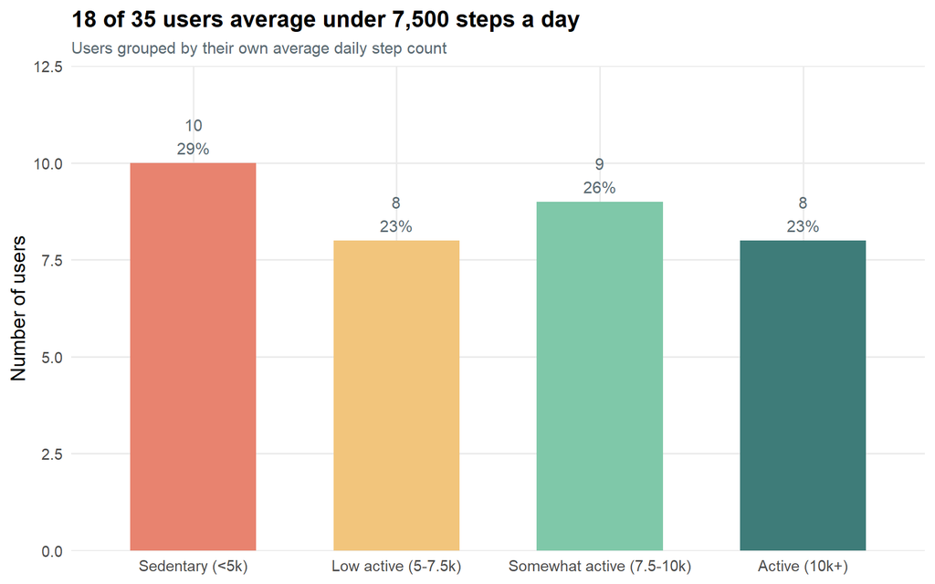

```r
user_avg <- worn |>  group_by(id) |>
  summarise(avg_steps = mean(total_steps), .groups = "drop") |>
  mutate(level = case_when(avg_steps < 5000  ~ "Sedentary (<5k)",
                           avg_steps < 7500  ~ "Low active (5-7.5k)",
                           avg_steps < 10000 ~ "Somewhat active (7.5-10k)",
                           TRUE              ~ "Active (10k+)") |>
           factor(levels = c("Sedentary (<5k)", "Low active (5-7.5k)",
                             "Somewhat active (7.5-10k)", "Active (10k+)")))

lvl <- user_avg |>  count(level, .drop = FALSE) |>  mutate(pct = n / sum(n))

ggplot(lvl, aes(level, n, fill = level)) +
  geom_col(width = .62) +
  geom_text(aes(label = paste0(n, "\n", percent(pct, 1))),
            vjust = -0.25, size = 3.6, colour = SLATE) +
  scale_y_continuous(expand = expansion(c(0, .25))) +
  scale_fill_manual(values = c(CORAL, SAND, MINT, TEAL), guide = "none") +
  labs(title = paste0(sum(lvl$n[1:2]), " of ", sum(lvl$n),
                      " users average under 7,500 steps a day"),
       subtitle = "Users grouped by their own average daily step count",
       x = NULL, y = "Number of users") + theme_bb
```

Mean daily steps were 8,057 and the Median 7,623. Only 34.0% of days Reached 10,000 steps.

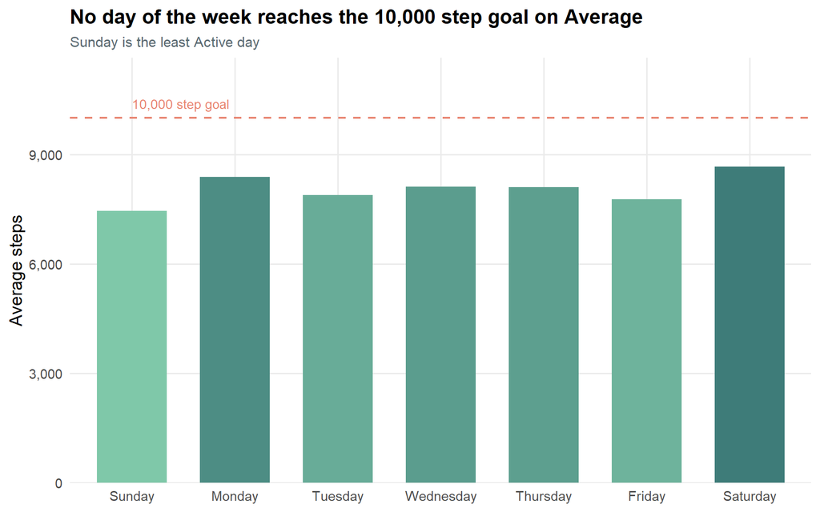

```r
worn |>  group_by(weekday) |>
  summarise(avg_steps = mean(total_steps), .groups = "drop") |>
  ggplot(aes(weekday, avg_steps, fill = avg_steps)) +
  geom_col(width = .68) +
  geom_hline(yintercept = 10000, linetype = "dashed", colour = CORAL, linewidth = .7) +
  annotate("text", x = 1, y = 10400, label = "10,000 step goal",
           colour = CORAL, size = 3.2, hjust = 0) +
  scale_fill_gradient(low = MINT, high = TEAL, guide = "none") +
  scale_y_continuous(labels = comma, expand = expansion(c(0, .12))) +
  labs(title = "No day of the week reaches the 10,000 step goal on Average",
       subtitle = "Sunday is the least Active day", x = NULL, y = "Average steps") +
  theme_bb
```

**Why that matters:** for half the user base the default goal is unreachable. A goal missed daily stops functioning as motivation and becomes a reminder of failure.

## Finding 3 : The problem is sitting, not exercising

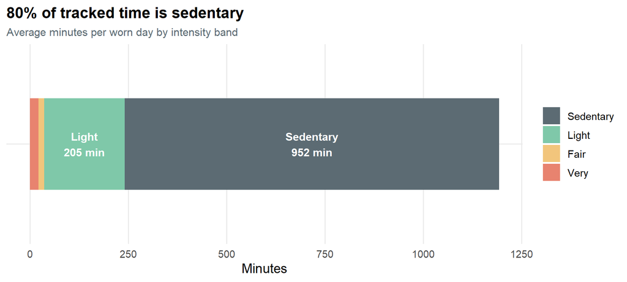

```r
mins <- worn |>
  summarise(Sedentary = mean(sedentary_minutes), Light = mean(lightly_active_minutes),
            Fair = mean(fairly_active_minutes), Very = mean(very_active_minutes)) |>
  pivot_longer(everything(), names_to = "intensity", values_to = "minutes") |>
  mutate(pct = minutes / sum(minutes),
         intensity = factor(intensity, levels = c("Sedentary", "Light", "Fair", "Very")))

ggplot(mins, aes("", minutes, fill = intensity)) +
  geom_col(width = .55) +
  geom_text(aes(label = ifelse(pct > .03, paste0(intensity, "\n", round(minutes), " min"), "")),
            position = position_stack(vjust = .5), size = 3.6,
            colour = "white", fontface = "bold") +
  coord_flip() + scale_fill_manual(values = c(SLATE, MINT, SAND, CORAL)) +
  labs(title = paste0(percent(mins$pct[mins$intensity == "Sedentary"], 1),
                      " of tracked time is sedentary"),
       subtitle = "Average minutes per worn day by intensity band",
       x = NULL, y = "Minutes", fill = NULL) +
  theme_bb + theme(axis.text.y = element_blank())
```

Users averaged 15.9 sedentary hours per tracked day against 21.7 very Active Minutes. On 55.8% of days, combined fairly and very Active time fell under 30 minutes.

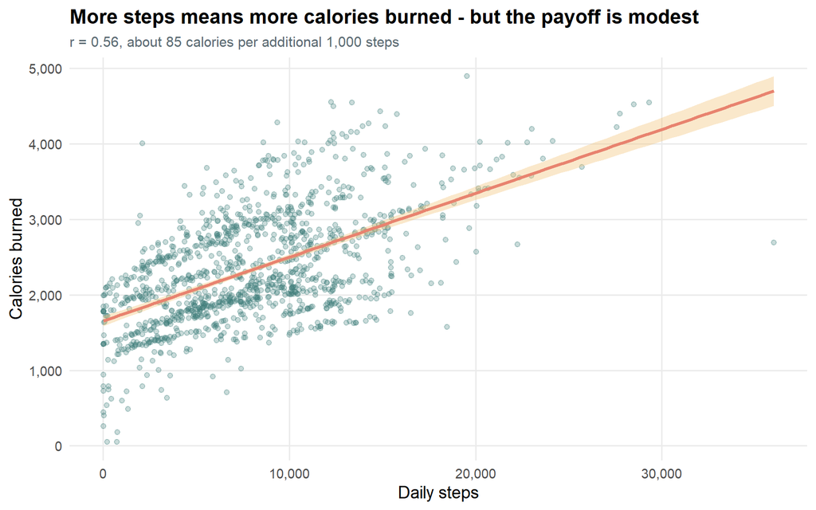

```r
ct <- cor.test(worn$total_steps, worn$calories)
m  <- lm(calories ~ total_steps, data = worn)

ggplot(worn, aes(total_steps, calories)) +
  geom_point(alpha = .28, colour = TEAL, size = 1.5) +
  geom_smooth(method = "lm", se = TRUE, colour = CORAL, fill = SAND) +
  scale_x_continuous(labels = comma) + scale_y_continuous(labels = comma) +
  labs(title = "More steps means more calories burned - but the payoff is modest",
       subtitle = paste0("r = ", round(ct$estimate, 2), ", about ",
                         round(coef(m)[2] * 1000), " calories per additional 1,000 steps"),
       x = "Daily steps", y = "Calories burned") + theme_bb
```

**Why that matters:** the addressable opportunity is the 15.9 sedentary hours, not the 22 active minutes. Breaking up sitting is a much lower bar for the user than adding workouts.

## Finding 4 : Activity clusters at two predictable peaks

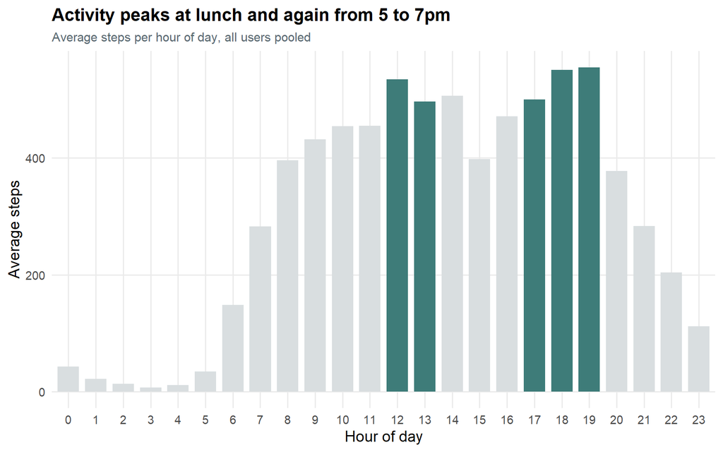

```r
by_hour <- hourly |>  group_by(hour) |>
  summarise(avg_steps = mean(step_total), .groups = "drop")

ggplot(by_hour |>  mutate(peak = hour %in% c(12, 13, 17, 18, 19)),
       aes(factor(hour), avg_steps, fill = peak)) +
  geom_col(width = .78) +
  scale_fill_manual(values = c(`FALSE` = GREY, `TRUE` = TEAL), guide = "none") +
  labs(title = "Activity peaks at lunch and again from 5 to 7pm",
       subtitle = "Average steps per hour of day, all users pooled",
       x = "Hour of day", y = "Average steps") + theme_bb
```

```r
by_hour |>  arrange(desc(avg_steps)) |>  head(5) |>
  transmute(Hour = paste0(hour, ":00"), `Average steps` = round(avg_steps)) |>
  kable(caption = "Five busiest Hours of the day")
```

Five busiest Hours of the day

| Hour | Average steps |
| --- | --- |
| 19:00 | 555 |
| 18:00 | 550 |
| 12:00 | 534 |
| 14:00 | 506 |
| 17:00 | 500 |

**Why that matters:** notification timing is guesswork for most apps. These windows are when users are already in motion and most receptive to a prompt.

## Finding 5 : Half of all nights falling short of healthy Sleep

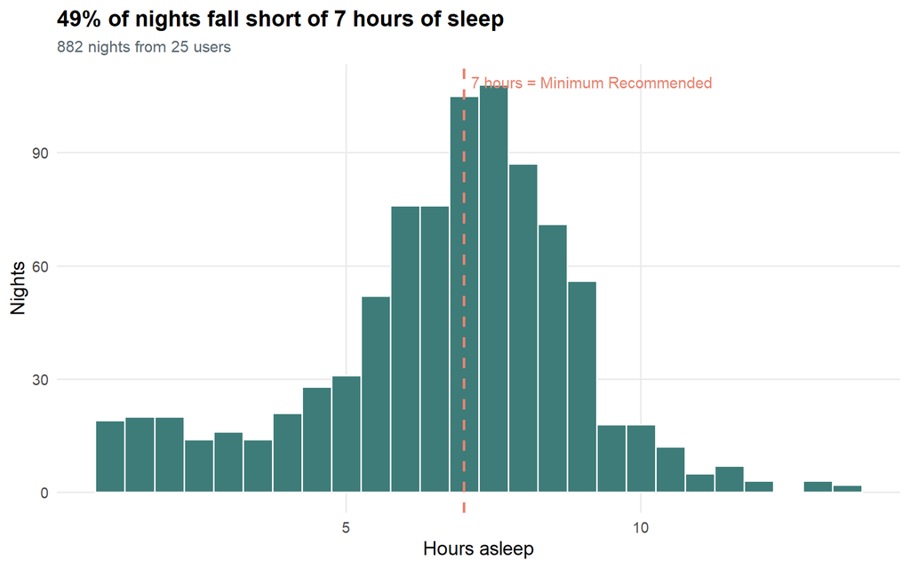

```r
ggplot(sleep, aes(hours_asleep)) +
  geom_histogram(binwidth = .5, fill = TEAL, colour = "white") +
  geom_vline(xintercept = 7, linetype = "dashed", colour = CORAL, linewidth = .8) +
  annotate("text", x = 7.12, y = Inf, vjust = 2, hjust = 0, colour = CORAL, size = 3.4,
           label = "7 hours = Minimum Recommended") +
  labs(title = paste0(percent(mean(sleep$hours_asleep < 7), 1),
                      " of nights fall short of 7 hours of sleep"),
       subtitle = paste0(nrow(sleep), " nights from ", n_distinct(sleep$id), " users"),
       x = "Hours asleep", y = "Nights") + theme_bb
```

Mean sleep was 6.68 hours, with an Average of 35.2 minutes spent awake in bed.

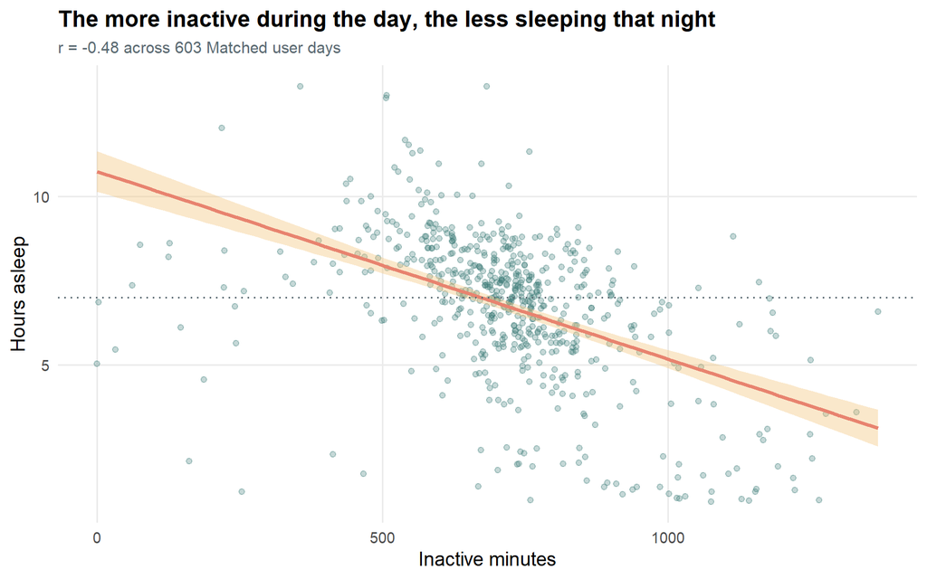

```r
ggplot(sa, aes(sedentary_minutes, hours_asleep)) +
  geom_point(alpha = .3, colour = TEAL, size = 1.5) +
  geom_smooth(method = "lm", se = TRUE, colour = CORAL, fill = SAND) +
  geom_hline(yintercept = 7, linetype = "dotted", colour = SLATE) +
  labs(title = "The more inactive during the day, the less sleeping that night",
       subtitle = paste0("r = ", round(cor(sa$sedentary_minutes, sa$hours_asleep), 2),
                         " across ", nrow(sa), " Matched user days"),
       x = "Inactive minutes", y = "Hours asleep") + theme_bb
```

**Why that matters:** this is the most actionable relationship in the dataset. The proposition is not “walk more, sleep better” but **“sit less, sleep better”** a concrete, defensible and differentiated claim.

## Finding 6 : Adoption Collapses when effort is needed

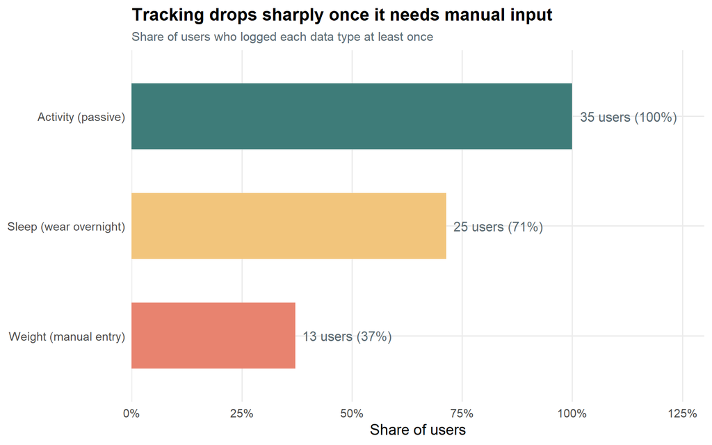

```r
adopt <- tibble(
  feature = c("Activity (passive)", "Sleep (wear overnight)", "Weight (manual entry)"),
  users   = c(n_distinct(daily$id), n_distinct(sleep$id), n_distinct(weight$id))
) |>  mutate(pct = users / n_users)

ggplot(adopt, aes(reorder(feature, pct), pct, fill = feature)) +
  geom_col(width = .6) +
  geom_text(aes(label = paste0(users, " users (", percent(pct, 1), ")")),
            hjust = -0.08, size = 3.8, colour = SLATE) +
  coord_flip() +
  scale_y_continuous(labels = percent, limits = c(0, 1.3), expand = c(0, 0)) +
  scale_fill_manual(values = c(TEAL, SAND, CORAL), guide = "none") +
  labs(title = "Tracking drops sharply once it needs manual input",
       subtitle = "Share of users who logged each data type at least once",
       x = NULL, y = "Share of users") + theme_bb
```

64.3% of weight entries were typed in by hand, with a median of 2 logs per logging user Across the whole window.

**Why it matters:** each increment of friction costs roughly a third of the user base. Features requiring manual input will not be adopted regardless of design quality.

# 6. Act : Recommendations

> **Deliverable 6: Top high level content Recommendations**

## Answers to the three useful questions

**1. What are some trends in smart device usage?** Devices are worn inconsistently a mMedian of 63% of days, with no user exceeding `80%`. Activity falls well short of public health targets: only 34.0% of days reach 10,000 steps, and 15.9 hours of the Average tracked day are sedentary. Activity concentrates at lunchtime and early evening. Sleep is short 49.1% of nights fall under seven hours and feature adoption drops sharply whenever manual input is required.

**2. How could these trends apply to Bellabeat Customers?** Bellabeat customers use the same categories of device for the same purposes, so the same behavioural ceilings apply. Two carry across most directly. First, wear rate caps everything: Bellabeat’s stress, sleep and the cycle features depend on consistent wear, so the Leaf’s Jewellery form factor Addresses a real constraint rather than a cosmetic one. Second, the restful sleep link maps precisely onto Bellabeat’s existing positioning around holistic wellness rather than athletic performance.

**3. How could these trends help influence Bellabeat marketing strategy?** They shift the message from performance to realism. Rather than competing with Fitbit and Apple on step counts and workout tracking where the data shows most users are failing Bellabeat can own the lower, more achievable and better evidenced proposition of sitting less to sleep better.

## Top three recommendations

### 1. Replace the fixed step goal with an adaptive one

Only 34.0% of days reach 10,000 steps and 18 of 35 users average under 7,500. Set each user’s initial target from their own first week baseline and raise it incrementally.

*Marketing line:* **“A goal that meets you where you are.”**

### 2. Market the app on the sit less, sleep better link

Inactive time predicts short sleep roughly three times more strongly than step count does (r = -0.48 against r = -0.15). Build the flagship app feature around this relationship, pairing hourly move reminders with the sleep score.

*Marketing line:* **“Sit less today, sleep better tonight.”**

### 3. Time notifications to the two peaks

Activity peaks at 12 to 2 p.m. and 5 to 7 p.m. Deliver movement prompts in those windows, the daily plan in the 7 a.m. lull, and a wind down prompt around 10 p.m This is the cheapest of the three to implement and the fastest to measure.

*Marketing line:* **“Nudges when you’re already moving.”**

## Supporting Recommendations

**4. Make the Leaf’s form factor the retention pitch.** Wear rate is the ceiling on every other feature. Market the Leaf as *“the tracker you don’t take off”*, and reward day after day **worn** rather than steps achieved.

**5. Eliminate manual logging.** Weight logging reached 37% of users. Assume any hand entry feature will fail; Prioritise Spring’s automatic hydration sync and smart scale integration.

# 7. Limitations and next steps

```r
tibble(
  Limitation = c("Sample size", "Gender data", "Data age", "Recruitment",
                 "Causality", "Sleep aggregation"),
  Detail = c(
    paste0(n_users, " participants too few to generalise to a consumer market"),
    "Not recorded, yet Bellabeat sells exclusively to women",
    paste0("Collected ", format(min(daily$date), "%b %Y"), " to ",
           format(max(daily$date), "%b %Y"), " nine years old"),
    "Self selected MTurk volunteers, unlikely to match Bellabeat's customer base",
    "The sedentary sleep link is an association; direction is untested",
    "March nights rely on a 6 a.m. cutoff assumption (see section 3.5)"
  )
) |>  kable(caption = "Constraints on these findings")
```

Constraints on these findings

[output not shown]

**These findings should be validated before budget is committed.** Recommended next steps, in order of cost:

1. **A/B test notification timing** against the 12 to 2 p.m and 5 to 7 p.m windows. Cheapest to run and fastest to prove or disprove.
2. **Replicate this analysis on Bellabeat’s own app telemetry**, where gender, age and product line are known the additional dataset Sršen suggested.
3. **Test the adaptive goal** against the fixed 10,000 step goal, measuring 30 day Active usage rather than step count.
4. **Survey lapsed users** on why the device came off, to confirm whether form factor is genuinely the binding constraint on wear rate.